# 이디야 & 컴포지 비교

## 2. 이디야 & 컴포즈 매장에서 스타벅스 매장까지의 최단거리( 각 매장에서 1000미터 이내 )

(이전 분석에서 두 브랜드 데이터를 도로네트워크 데이터와 결합하여 최단거리 데이터셋을 구축함.)

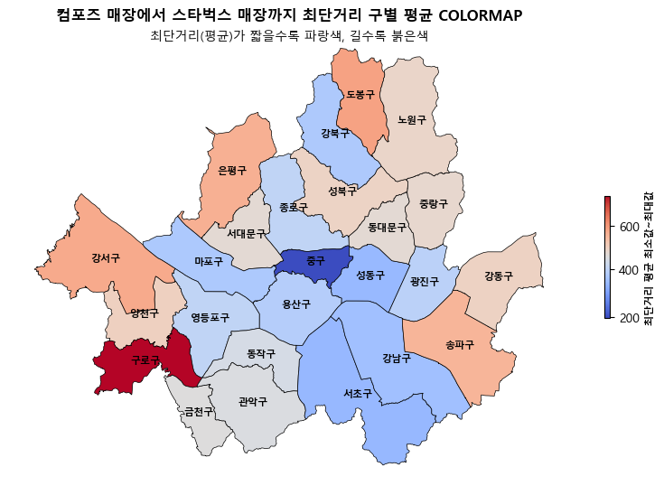

```python
add_text_sb = '최단거리(평균)가 짧을수록 파랑색, 길수록 붉은색'
title_text = '컴포즈 매장에서 스타벅스 매장까지 최단거리 구별 평균 COLORMAP'
map_color_text(sigu,'sb_평균거리_cp','coolwarm','최단거리 평균 최소값~최대값','SIG_KOR_NM',add_text_sb,title_text)
```

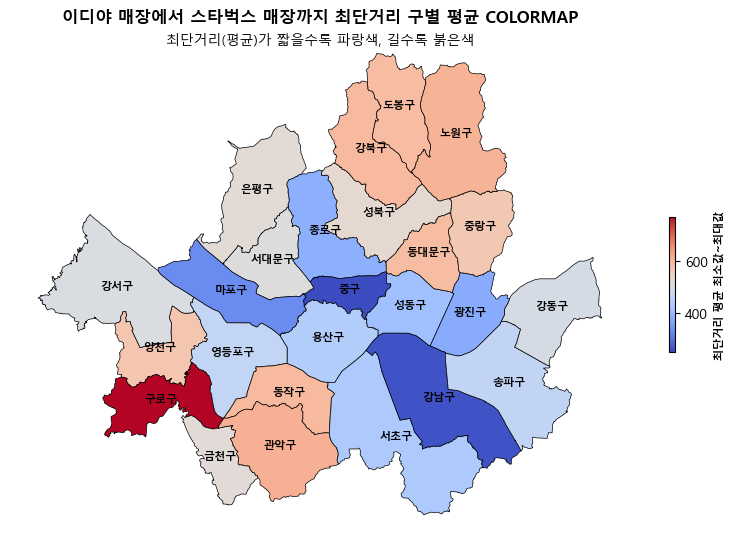

```python
add_text_sb = '최단거리(평균)가 짧을수록 파랑색, 길수록 붉은색'
title_text = '이디야 매장에서 스타벅스 매장까지 최단거리 구별 평균 COLORMAP'
map_color_text(sigu,'sb_평균거리_ed','coolwarm','최단거리 평균 최소값~최대값','SIG_KOR_NM',add_text_sb,title_text)
```

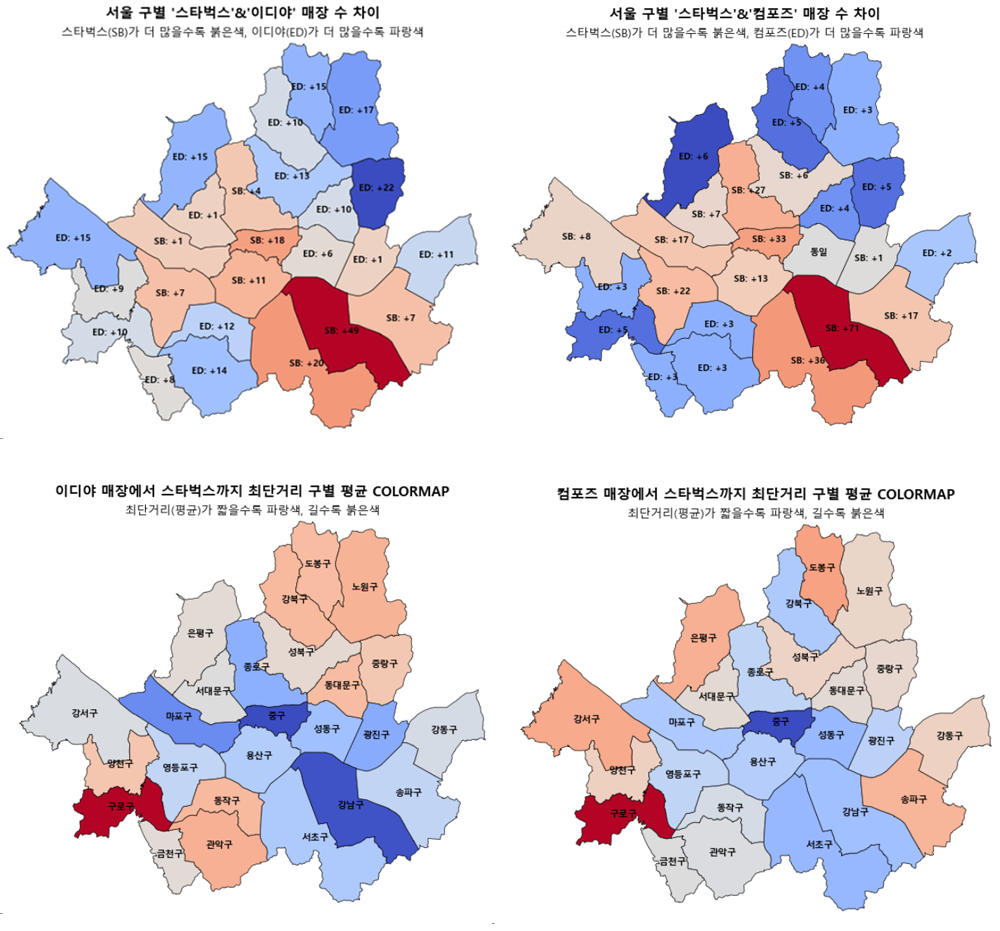

```python
Image('seoul_ed_cp01.png')
```

'입지환경분석 1 - 입지환경 1_1.'에서 서울은 공시지가가 높고 전철역 수가 많은 구(A)와 그렇지 않은 구(B)로 구분 될 수 있음을 COLORMAP으로 확인하였다.  
4개의 COLORMAP에서 A구와 B구로 대체로 구분됨을 확인 할 수 있다.  
● 스타벅스와 매장 수 차이 : 두 브랜드 모두 A구들에서 스타벅스의 매장 수가 B구들보다 더 많다.  
● 스타벅스까지 최단거리 : 두 브랜드 모두 A구들에서 스타벅스까지 최단거리가 B구들보다 더 짧다.(매장 수 차이에 의한 효과로 보임)

## 3. 스타벅스 매장까지 두 브랜드 최단거리 평균 차이 분석(거리 제한 없음)

### 3_1. 컴포즈 최단거리(평균) & 이디야 최단거리(평균) 차이 확인

컴포즈 서울 매장 수:402, 이디야 서울 매장 수 : 686  
(이전 분석에서 두 브랜드 데이터를 도로네트워크 데이터와 결합하여 최단거리 데이터셋을 구축함.)

```python
compo_sb.head(3)
```

|  | gu | title | address | lat | lng | longitude | latitude | dist2sub | dist2sub_p |
| --- | --- | --- | --- | --- | --- | --- | --- | --- | --- |
| 0 | 강남구 | 강남포이점 | 서울 강남구 개포로 223 101호 102호 | 37.478961 | 127.047255 | 959970.510251 | 1.942288e+06 | 292.980 | 4.184550e+09 |
| 1 | 강남구 | 역삼개나리점 | 서울 강남구 언주로 405 (역삼동) | 37.500078 | 127.038542 | 959211.611316 | 1.944635e+06 | 489.720 | 5.418416e+09 |
| 2 | 강남구 | 도곡매봉점 | 서울 강남구 남부순환로 2738 (도곡동, 상일빌딩) | 37.483074 | 127.042965 | 959593.457656 | 1.942747e+06 | 112.119 | 8.500235e+09 |

```python
ediya_sb.head(3)
```

|  | gu | title | address | lat | lng | longitude | latitude | dist2sub | dist2sub_p |
| --- | --- | --- | --- | --- | --- | --- | --- | --- | --- |
| 0 | 강남구 | 강남YMCA점 | 서울 강남구 논현동 | 37.513679 | 127.031712 | 958615.455900 | 1.946147e+06 | 251.327 | 1.326158e+09 |
| 1 | 강남구 | 강남구청역아이티웨딩점 | 서울 강남구 학동로 338 (논현동, 강남파라곤) | 37.516551 | 127.040139 | 959361.720736 | 1.946462e+06 | 178.689 | 4.181719e+09 |
| 2 | 강남구 | 강남논현학동점 | 서울 강남구 논현로131길 28 (논현동) | 37.515190 | 127.027554 | 958248.791495 | 1.946316e+06 | 322.329 | 1.326158e+09 |

```python
compo_mean = compo_sb['dist2sub'].mean()
ediya_mean = ediya_sb['dist2sub'].mean()
print("컴포즈 최단거리 평균: "+str(round(compo_mean,2)))
print("이디야 최단거리 평균: "+str(round(ediya_mean,2)))
```

```
컴포즈 최단거리 평균: 528.28
이디야 최단거리 평균: 539.18
```

#### 스타벅스 매장까지 최단거리 평균에 있어서 컴포즈가 이디야보다 11m 더 짧다.

히스토그램

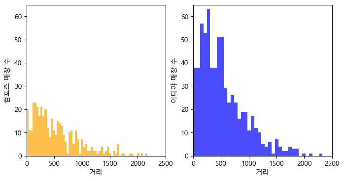

```python
import matplotlib.pyplot as plt
import seaborn as sns

fig, axs = plt.subplots(1, 2, figsize=(8,4))
axs[0].hist(compo_sb['dist2sub'], bins=60, alpha=0.7, color='orange')
axs[0].set_xlabel('거리')
axs[0].set_ylabel('컴포즈 매장 수')

axs[1].hist(ediya_sb['dist2sub'], bins=60, alpha=0.7, color='blue')
axs[1].set_xlabel('거리')
axs[1].set_ylabel('이디야 매장 수')

axs[0].set_ylim(0,65)
axs[1].set_ylim(0,65)
axs[0].set_xlim(0,2500)
axs[1].set_xlim(0,2500)

plt.show()
```

### 3_2. 이디야&컴포즈 스타벅스 최단거리에 따른 매장 수

```python
pd.options.display.float_format = None   # 소수점을 모두 표시
with open('neardata.pkl', 'rb') as file:
    neardata = pickle.load(file)
```

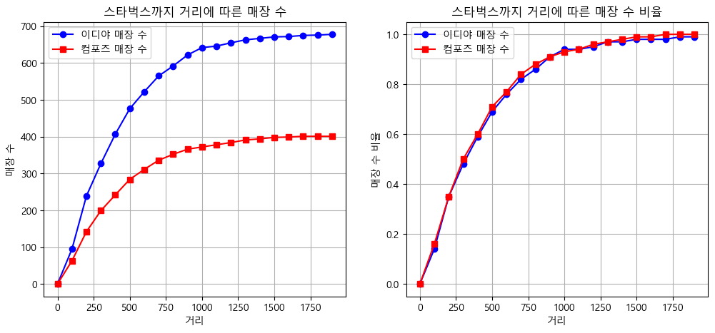

```python
fig, axs = plt.subplots(1, 2, figsize=(12, 5))

axs[0].plot(neardata['dist'], neardata['near_ed'], label='이디야 매장 수', marker='o', color='b')  # 파란색 선
axs[0].plot(neardata['dist'], neardata['near_com'], label='컴포즈 매장 수', marker='s', color='r')  # 빨간색 선
axs[0].set_title('스타벅스까지 거리에 따른 매장 수')
axs[0].set_xlabel('거리')
axs[0].set_ylabel('매장 수')
axs[0].legend()
axs[0].grid()

axs[1].plot(neardata['dist'], neardata['near_ed_1'], label='이디야 매장 수', marker='o', color='b')  # 파란색 선
axs[1].plot(neardata['dist'], neardata['near_com_1'], label='컴포즈 매장 수', marker='s', color='r')  # 빨간색 선
axs[1].set_title('스타벅스까지 거리에 따른 매장 수 비율')
axs[1].set_xlabel('거리')
axs[1].set_ylabel('매장 수 비율')
axs[1].legend()
axs[1].grid()
```

#### 왼쪽 그래프 : 스타벅스까지 거리에 따른 매장 수는 두 브랜드 모두 1000m까지 급격히 증가함을 볼 수 있다.

#### 오른쪽 그래프 : 두 브랜드의 매장 수 비율로 확인하면 거리에 따른 매장 수 비율은 거의 같다.( 거리별 매장 수 / 전체 매장 수 )

## 4. 분석 결론

#### ''입지환경분석 1 - 입지환경 1_1.''에서 서울은 공시지가가 높고 전철역 수가 많은 구(A)와 그렇지 않은 구(B)로 구분 될 수 있음을 COLORMAP으로 확인하였다.

#### 두 브랜드의 매장 수와 스타벅스까지 최단거리는 A구와 B구로 구분된 동일한 양상을 보인다.

#### 스타벅스 매장까지 최단거리 평균에 있어서 컴포즈가 이디야보다 11m 더 짧다.

#### 두 브랜드의 매장 수 비율로 확인하면 거리에 따른 매장 수 비율은 거의 같다.

#### 따라서 스타벅스 매장 인접한 지역에 이디야 매장이 전략적으로 입점한다고 단정하기는 어렵다.

## 추가 분석 - 최단경로 도로네트워크 지도상 확인

지하철역 여러 호선이 있는 역 리네임

```python
num = subway[subway['SUBWAY_STA'].isnull()].index.tolist()
subway['SUBWAY_STA'][num] = "noname역"
subway = duplicate_rename(subway)
```

지하철역이 속한 구 할당

```python
SIG_KOR_NM = []
for i in range(subway.shape[0]):
    subim = subway.loc[subway['SUBWAY_STA'] == subway['SUBWAY_STA'][i], 'geometry'].values[0]# squeeze()를 하면 오류난다.
    for j in range(sigu.shape[0]):
        guim = sigu.loc[sigu['SIG_KOR_NM'] == sigu['SIG_KOR_NM'][j], 'geometry'].values[0]
        subim.within(guim)
        if subim.within(guim)==True:
            SIG_KOR_NM.append(sigu['SIG_KOR_NM'][j])
    if len(SIG_KOR_NM)<(i+1):
        SIG_KOR_NM.append('없음')
subway['SIG_KOR_NM'] = SIG_KOR_NM
```

```python
sigu.loc[[15,22],['SIG_KOR_NM','starbucks_count','ediya_count','sb_id_1','평균거리_sb','평균거리_ed','평균거리_차이']]
```

|  | SIG_KOR_NM | starbucks_count | ediya_count | sb_id_1 | 평균거리_sb | 평균거리_ed | 평균거리_차이 |
| --- | --- | --- | --- | --- | --- | --- | --- |
| 15 | 강서구 | 28 | 43 | ED: +15 | 378 | 512 | 134 |
| 22 | 강남구 | 91 | 42 | SB: +49 | 489 | 553 | 63 |

```
강남구의 경우 이디야의 최단거리(평균)가 스타벅스보다 64m 더 길다.
```

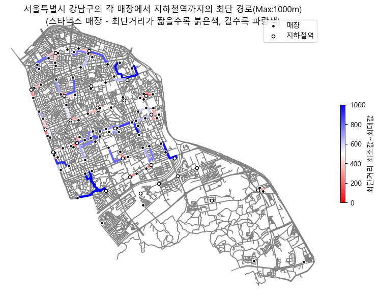

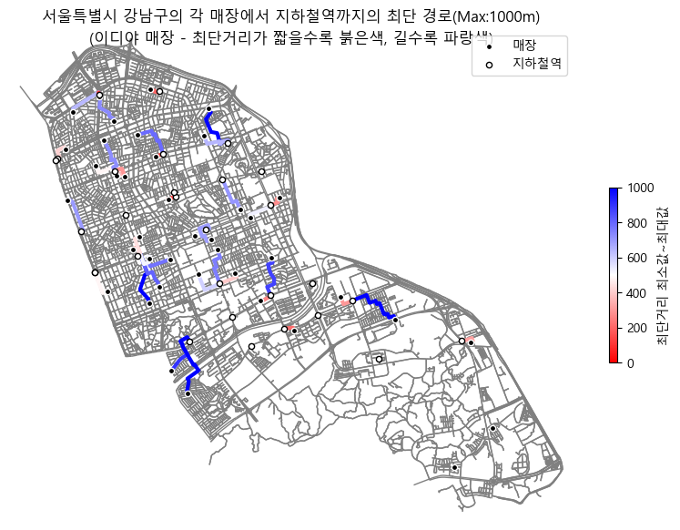

```python
gu_near_vi('G_gang.pkl','강남구')
```

강남구-스타벅스의 경우 파랑색 경로가 붉은색(또는 흰색)보다 조금 더 많다. 이디야의 경우는 파랑색 경로가 훨신 더 많다.

```
강서구의 경우 이디야의 최단거리(평균)가 스타벅스보다 134m 더 길다.
```

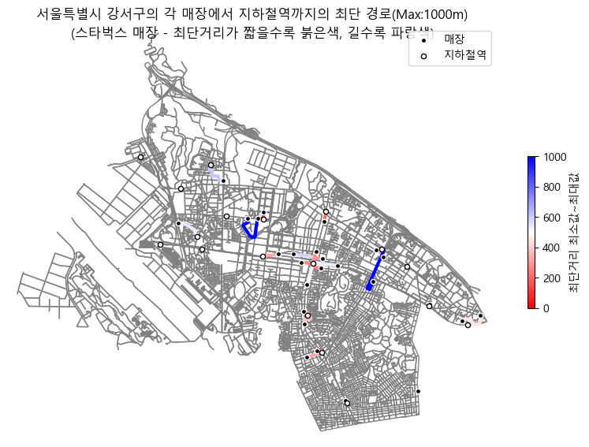

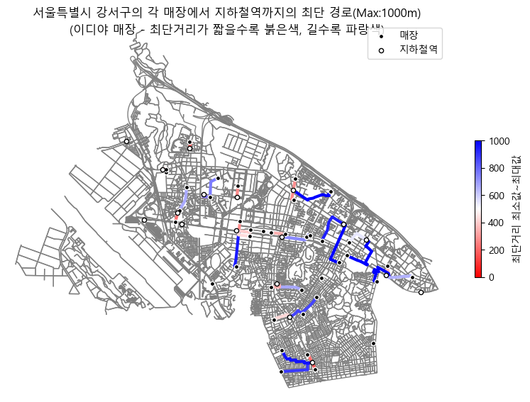

```python
gu_near_vi('G_gangsu.pkl','강서구')
```

강서구-스타벅스의 경우 파랑색 경로보다 붉은색(또는 흰색) 경로가 훨씬 더 많다. 이디야의 경우는 파랑색 경로가 더 많다.

### 함수 코드

```python
# 최근접 지하철역 노드, 거리 반환
def nearest_fun(G_utm,nearest_sb,nearest_sub,df):
    shortest_dist2sub = []
    shortest_dist2sub_p = []
    for i in tqdm(range(len(nearest_sb))):
        centroid_point = (G_utm.nodes[nearest_sb[i]]['x'], G_utm.nodes[nearest_sb[i]]['y'])
        buffer = Point(centroid_point).buffer(1000)
        # 1000미터 이내의 지하철역 찾기 ======================================================================
        temp = []
        temp_sub = []
        for j in range(len(nearest_sub)):
            subway_point_xy = (G_utm.nodes[nearest_sub[j]]['x'], G_utm.nodes[nearest_sub[j]]['y'])
            if buffer.contains(Point(subway_point_xy)):
                try:
                    dist = nx.shortest_path_length(G_utm, nearest_sb[i], nearest_sub[j],weight='length')
                    temp.append(dist)
                    temp_sub.append(nearest_sub[j])
                except:
                    pass
        if len(temp) > 0 :
            shortest_dist2sub.append(min(temp))
            shortest_dist2sub_p.append(temp_sub[temp.index(min(temp))])
        else:
            shortest_dist2sub.append(None)
            shortest_dist2sub_p.append(None)

    df['dist2sub'] = shortest_dist2sub
    df['dist2sub_p'] = shortest_dist2sub_p
    return(df)
```

```python
# 최근접 지하철역 경로 시각화
def nearest_vi_1(G_utm,nearest,nearest_sub,size1,size2,nd_color,inout,range1,mark_size1,mark_size2,mk_color1,mk_color2,rou_alpha,gu,add_text ):
    import matplotlib.cm as cm
    import matplotlib.colors as mcolors

    viewer = inout
    if viewer=='out':
        %matplotlib tk
    if viewer=='in':
        %matplotlib inline
    fig, ax = plt.subplots(figsize=(size1,size2))
    ox.plot_graph(G_utm, ax=ax, node_size=0, edge_color='gray', show=False, close=False)

    # 컬러맵 설정
    cmap = cm.get_cmap(nd_color)
    norm = mcolors.Normalize(vmin=0, vmax= range1 )
    for i in range(len(nearest)):
        centroid_point = (G_utm.nodes[nearest[i]]['x'], G_utm.nodes[nearest[i]]['y'])
        buffer = Point(centroid_point).buffer(range1)
        temp = []
        temp_sub = []

        for j in range(len(nearest_sub)):
            subway_point_xy = (G_utm.nodes[nearest_sub[j]]['x'], G_utm.nodes[nearest_sub[j]]['y'])
            if buffer.contains(Point(subway_point_xy)):
                try:
                    dist = nx.shortest_path_length(G_utm, nearest[i], nearest_sub[j], weight='length')
                    temp.append(dist)
                    temp_sub.append(nearest_sub[j])
                except:
                    pass

        if len(temp) > 0:
            shortest_path = nx.shortest_path(G_utm, nearest[i], temp_sub[temp.index(min(temp))], weight='length')
            path_length = temp[temp.index(min(temp))]
            color = cmap(norm(path_length))
            ox.plot_graph_route(G_utm, shortest_path, ax=ax,route_alpha=rou_alpha , route_linewidth=3, route_color=color,orig_dest_size=0, show=False, close=False)

    nearest_x = [G_utm.nodes[nearest[idx]]['x'] for idx in range(len(nearest)) ]
    nearest_y = [G_utm.nodes[nearest[idx]]['y'] for idx in range(len(nearest)) ]
    ax.scatter(nearest_x,nearest_y, color='black', s=mark_size1, alpha=1, zorder=5, edgecolor=mk_color1,label='매장')

    nearest_sub_x = [G_utm.nodes[nearest_sub[idx]]['x'] for idx in range(len(nearest_sub)) ]
    nearest_sub_y = [G_utm.nodes[nearest_sub[idx]]['y'] for idx in range(len(nearest_sub)) ]
    ax.scatter(nearest_sub_x,nearest_sub_y, color='white', s=mark_size2, alpha=1, zorder=5, edgecolor=mk_color2,label='지하철역')
    plt.legend(loc='upper right')
    plt.title('서울특별시 '+gu+'의 각 매장에서 지하철역까지의 최단 경로(Max:1000m)')
    plt.colorbar(cm.ScalarMappable(norm=norm, cmap=cmap), ax=ax, label='최단거리 최소값~최대값',shrink=0.25) # shrink 막대그래프 범례 크기
    plt.text(0.5,0.98, add_text, ha='center', va='center', transform=ax.transAxes, fontsize=12)
    plt.show()

def gnode_near_vi(G_mapo,sub_mapo_arr,starbucks_mapo,gu,add_text):
    n_mapo_sub, d_mapo_sub = ox.distance.nearest_nodes(G_mapo, X=sub_mapo_arr[:,0], Y=sub_mapo_arr[:,1], return_dist=True)
    n_mapo_sb, d_mapo_sb      = ox.distance.nearest_nodes(G_mapo, X=starbucks_mapo['longitude'], Y=starbucks_mapo['latitude'], return_dist=True)
    nearest_vi_1(G_mapo,n_mapo_sb,n_mapo_sub,10,10,'bwr_r','in',1000,20,20,'white','black',1,gu,add_text)

def gu_near_vi(pkl,gu):
    with open(pkl, 'rb') as file:
        G_gang = pickle.load(file)
    subway_gang = subway[subway['SIG_KOR_NM']==gu]
    sub_gang_arr = sub_crds_arr[subway_gang.index]
    starbucks_gang = starbucks[starbucks['gu']==gu]
    ediya_gang = ediya[ediya['gu']==gu]
    mean_sub = round(starbucks_gang['dist2sub'].mean()) - round(ediya_gang['dist2sub'].mean())
    if mean_sub < 0:
        sub_text = gu+'의 경우 이디야의 최단거리(평균)가 스타벅스보다 '+str(mean_sub*-1)+'m 더 길다.'
    else:
        sub_text = gu+'의 경우 이디야의 최단거리(평균)가 스타벅스보다 '+str(mean_sub*-1)+'m 더 짧다.'
    print(sub_text)
    gnode_near_vi(G_gang,sub_gang_arr,starbucks_gang,gu,"(스타벅스 매장 - 최단거리가 짧을수록 붉은색, 길수록 파랑색)")
    gnode_near_vi(G_gang,sub_gang_arr,ediya_gang,gu,"(이디야 매장 - 최단거리가 짧을수록 붉은색, 길수록 파랑색)")
```

```python
# 지하철역명 중복 리넴임
def find_duplicate_indices(lst):
    from collections import defaultdict
    indices_dict = defaultdict(list)
    for index, value in enumerate(lst):
        indices_dict[value].append(index)
    duplicates = {key: indices for key, indices in indices_dict.items() if len(indices) > 1}
    return duplicates

def duplicate_rename(subway):
    dup_dict = find_duplicate_indices(subway['SUBWAY_STA'])
    imkey = []
    imvalue = []
    for key, value in dup_dict.items():
        imkey.append(key)
        imvalue.append(value)
    for i in range(len(imkey)):
        for j in range(len(imvalue[i])):
            if j==0:
                subname = subway.loc[imvalue[i][j],'SUBWAY_STA']
            else:
                subway['SUBWAY_STA'][imvalue[i][j]] = subname+str(j)
    return(subway)
```